# pacdev_assignment_PM

Prabhudatta Mohapatra

03/26/2023

```r
#loading libraries
library(tidyverse)
library(ggplot2)
library(dplyr)
```

```r
#importing data
pacd<- read.csv("pacdev_data.csv")
#checking data summary
summary(pacd)
```

```
##      city               pool              garage               sqft
##  Length:4991        Length:4991        Length:4991        Min.   : 942
##  Class :character   Class :character   Class :character   1st Qu.:1736
##  Mode  :character   Mode  :character   Mode  :character   Median :1988
##                                                           Mean   :2013
##                                                           3rd Qu.:2292
##                                                           Max.   :3298
##       bed              bath           price
##  Min.   : 1.000   Min.   :1.000   Min.   :  91062
##  1st Qu.: 2.000   1st Qu.:1.000   1st Qu.: 412285
##  Median : 3.000   Median :2.000   Median : 575422
##  Mean   : 2.998   Mean   :2.143   Mean   : 582699
##  3rd Qu.: 4.000   3rd Qu.:3.000   3rd Qu.: 741030
##  Max.   :10.000   Max.   :9.000   Max.   :1500570
```

```r
str(pacd)
```

```
## 'data.frame':    4991 obs. of  7 variables:
##  $ city  : chr  "Santa Monica" "Long Beach" "Westwood" "Westwood" ...
##  $ pool  : chr  "no" "no" "no" "yes" ...
##  $ garage: chr  "yes" "no" "no" "yes" ...
##  $ sqft  : int  2343 1705 1846 1782 2257 2098 1838 1907 1842 1474 ...
##  $ bed   : int  1 1 3 2 1 4 2 4 2 2 ...
##  $ bath  : int  1 1 2 1 1 3 1 3 1 1 ...
##  $ price : int  537227 432815 495542 151566 784151 369506 456937 503307 485277 650842 ...
```

## Q1

```r
#liner regression summary
summary(lm(price~sqft,data = pacd))
```

```
##
## Call:
## lm(formula = price ~ sqft, data = pacd)
##
## Residuals:
##     Min      1Q  Median      3Q     Max
## -622948 -151283   -1650  138951  804553
##
## Coefficients:
##              Estimate Std. Error t value Pr(>|t|)
## (Intercept) 40623.019  15862.454   2.561   0.0105 *
## sqft          269.345      7.742  34.791   <2e-16 ***
## ---
## Signif. codes:  0 '***' 0.001 '**' 0.01 '*' 0.05 '.' 0.1 ' ' 1
##
## Residual standard error: 210300 on 4989 degrees of freedom
## Multiple R-squared:  0.1953, Adjusted R-squared:  0.1951
## F-statistic:  1210 on 1 and 4989 DF,  p-value: < 2.2e-16
```

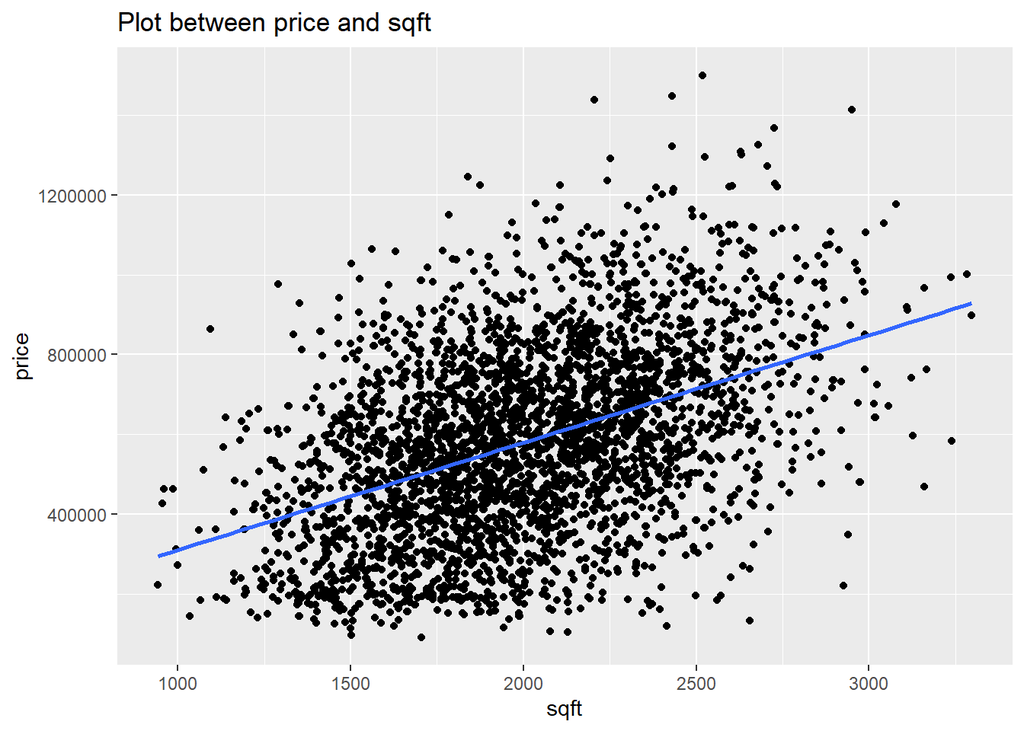

```r
#price and sqft plot with summary linear regression line
ggplot(pacd,aes(sqft,price)) +
  geom_jitter() +
  geom_smooth(formula = y~ x,method = 'lm',se = F) +
  labs(title = "Plot between price and sqft")
```

> From the above summary of the linear regression we can write the equation of the summary line as: price = (269.345 * sqft) + 40623.019. As the sqft co-efficient is positive it signifies that there is a positive relatinoship between sqft and price or as sqft increases price of home increases. Same can be derived looking at the regression line positive slope. Also, sqft co-efficient 269.345 suggests that 1 unit increase in sqft is associated with an increase of $269.35 in price of the home, on average. The coefficient for sqft (269.345) is statistically significant at the p < 0.001 level. For intercept the coefficient is 40623.019, which is the average value of price when there sqft is zero (0), which also states that the home prices starts at $40623.02, on average.

## Q2

```r
#centering the sqft
pacd<- pacd %>%
  mutate(centered_sqft = (sqft - mean(sqft)))

#multiple regression model
summary(lm(price ~ city + pool + garage  + bed + bath + centered_sqft, data = pacd))
```

```
##
## Call:
## lm(formula = price ~ city + pool + garage + bed + bath + centered_sqft,
##     data = pacd)
##
## Residuals:
##     Min      1Q  Median      3Q     Max
## -539286 -137407   -3532  124838  852187
##
## Coefficients:
##                    Estimate Std. Error t value Pr(>|t|)
## (Intercept)      528103.213   9291.990  56.834   <2e-16 ***
## citySanta Monica 190239.704   6757.751  28.151   <2e-16 ***
## cityWestwood      88020.719   6794.984  12.954   <2e-16 ***
## poolyes           10124.630   6760.090   1.498   0.1343
## garageyes        -14195.911   6120.799  -2.319   0.0204 *
## bed                  41.553   8420.185   0.005   0.9961
## bath              -3092.909   9439.900  -0.328   0.7432
## centered_sqft       271.561      7.515  36.138   <2e-16 ***
## ---
## Signif. codes:  0 '***' 0.001 '**' 0.01 '*' 0.05 '.' 0.1 ' ' 1
##
## Residual standard error: 195000 on 4983 degrees of freedom
## Multiple R-squared:  0.3085, Adjusted R-squared:  0.3075
## F-statistic: 317.6 on 7 and 4983 DF,  p-value: < 2.2e-16
```

> From the above model summary the equation of the regression line: price = 528103.213 + (190239.704 * citySanta Monica) + (88020.719 * cityWestwood) + (10124.630 * poolyes) - (14195.911 * garagyes) + (41.553 * bed) - (3092.909 * bath) + (271.561 * centered_sqft)

> Interpretation of coefficients:

> `Intercept`: 528103.213 is average price for homes when city = Long Beach, Pool = No, garage = No, bed = 0, bath = 0, and centered_sqft = 0 (which states average the starting price of homes considering adjusted variables)

> `centered_sqft`: an increase of 1 sqft is associated with an increase of $271.56 in the price of home, on average

> `citySanta Monica`: 190239.704 is the average difference in home price comparing Long Beach to Santa Monica

> `cityWestwood`: 88020.719 is the average difference in home price comparing Long Beach to Westwood.

## Q3

```r
#interaction model & summary
summary(lm(price ~ pool + garage  + bed + bath + centered_sqft * city, data = pacd))
```

```
##
## Call:
## lm(formula = price ~ pool + garage + bed + bath + centered_sqft *
##     city, data = pacd)
##
## Residuals:
##     Min      1Q  Median      3Q     Max
## -536726 -138828   -2505  124312  868332
##
## Coefficients:
##                                 Estimate Std. Error t value Pr(>|t|)
## (Intercept)                    527445.45    9270.43  56.895  < 2e-16 ***
## poolyes                         10817.17    6744.71   1.604   0.1088
## garageyes                      -14205.98    6108.49  -2.326   0.0201 *
## bed                               235.26    8403.39   0.028   0.9777
## bath                            -3099.26    9419.64  -0.329   0.7422
## centered_sqft                     240.63      10.14  23.726  < 2e-16 ***
## citySanta Monica               189904.29    6741.32  28.170  < 2e-16 ***
## cityWestwood                    88037.11    6778.98  12.987  < 2e-16 ***
## centered_sqft:citySanta Monica     90.09      17.49   5.152 2.68e-07 ***
## centered_sqft:cityWestwood         37.95      18.05   2.103   0.0356 *
## ---
## Signif. codes:  0 '***' 0.001 '**' 0.01 '*' 0.05 '.' 0.1 ' ' 1
##
## Residual standard error: 194500 on 4981 degrees of freedom
## Multiple R-squared:  0.3122, Adjusted R-squared:  0.311
## F-statistic: 251.2 on 9 and 4981 DF,  p-value: < 2.2e-16
```

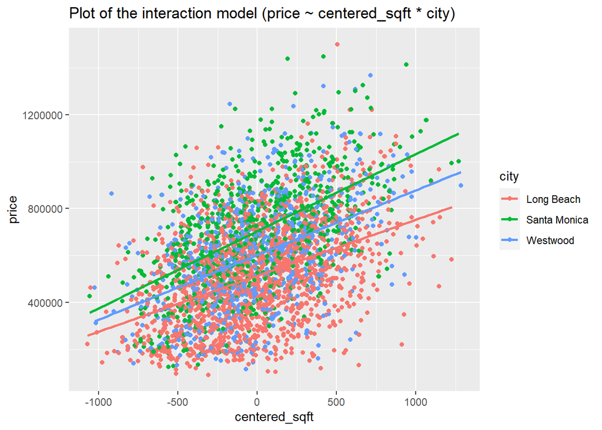

```r
#interaction model plot (price ~ centered_sqft * city)
ggplot(pacd,aes(centered_sqft, price, col = city)) +
  geom_jitter() +
  geom_smooth(formula= y ~ x, method = 'lm', se = FALSE) +
  labs(title = "Plot of the interaction model (price ~ centered_sqft * city)")
```

> Above summary and graph represents home sale price model having an interaction between centered_sqft and city.

> Interpretation of coefficients:

> `Intercept`: 527445.45 is average price for homes when city = Long Beach, Pool = No, garage = No, bed = 0, bath = 0, and centered_sqft = 0 (which states average starting price of homes considering adjusted variables)

> `centered_sqft`: as per the interaction model an increase of 1 sqft is associated with an increase of $240.63 in the price of home, on average. It is statistically significant.

> `citySanta Monica`: 189904.29 is the average difference in home price comparing Long Beach to Santa Monica. It is statistically significant.

> `cityWestwood`: 88037.11 is the average difference in home price comparing Long Beach to Westwood. It is statistically significant.

> `centered_sqft:citySanta Monica`: 90.09 is the average difference in the relationship between centered_sqft and home sale price for Long Beach vs. Santa Monica. The relationship can be stated the other way around also: 90.09 is the average difference in the relationship between city (Long Beach vs. Santa Monica) and home sale price for 1 unit change in the centered_sqft. The coefficient 90.09 estimate the change in the slope of the regression line for Santa Monica compared to Long Beach. As the coefficient is positive that means the regression line relating sqft to price is steeper for Santa Monica in comparison to Long Beach and there is a strong relationship. . It is statistically significant.

> Also, it can be observed that Santa Monica city interaction with centered_sqft has the highest interaction effect for price when compared to other cities (Long Beach, Westwood) combination with centered_sqft. Same can be observed from the interaction model plot that Santa Monica city home sale price has the highest positive slope (price and centered_sqft*city) among all the cities.

## Q4

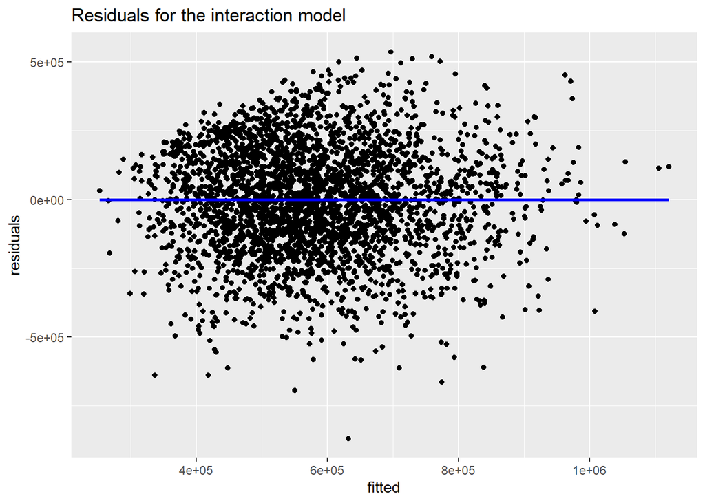

```r
# Model assessment
#residual plot
pacd %>%
  mutate(fitted = fitted(lm(price ~ pool + garage  + bed + bath + centered_sqft * city, data = pacd)),
      residuals = fitted-price) %>%
  ggplot(aes(fitted, residuals)) +
  geom_point() +
  geom_smooth(formula=y~x,method = "lm", se = F, col = "blue") +
  labs(title = "Residuals for the interaction model")
```

> From the residual plot we can observe that the residuals are randomly distributed around the summary line or residual line = 0. Also, from visual inspection we do not see any pattern in residual distribution which satisfies the condition for selecting the correct regression technique for modeling. So, we can conclude that a linear regression model is appropriate for modeling this particular data.

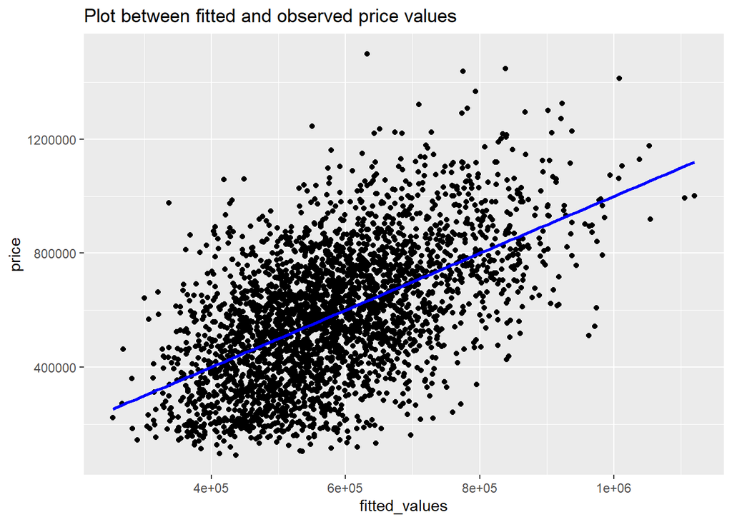

```r
#extracting fitted values
fitted_values<-fitted(lm(price ~ pool + garage  + bed + bath + centered_sqft * city, data = pacd))

#fitted values vs observed values plot for price
ggplot(pacd,aes(fitted_values, price)) +
  geom_point() +
  geom_smooth(formula=y~x,method = "lm", se = F, col = "blue")+
  labs(title = "Plot between fitted and observed price values")
```

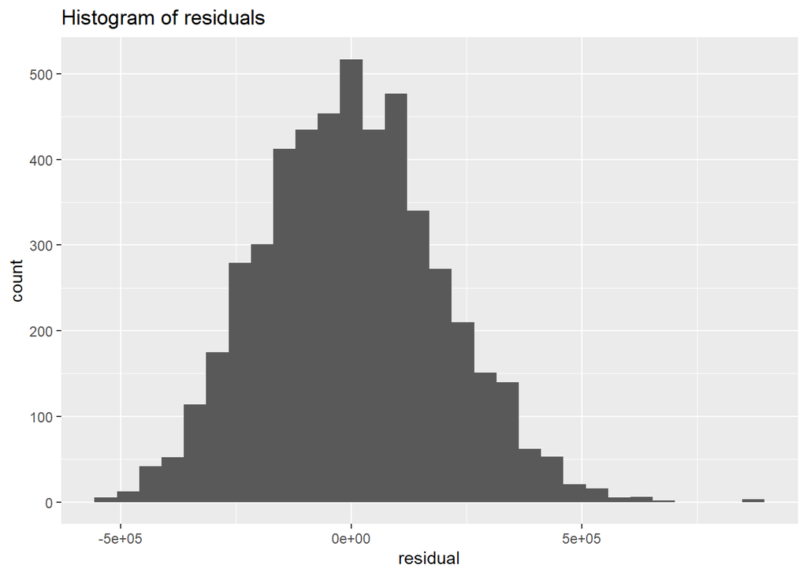

```r
#extracting residuals
residual<-resid(lm(price ~ pool + garage  + bed + bath + centered_sqft * city, data = pacd))
# histogram of residuals
ggplot(pacd, aes(residual)) +
  geom_histogram(bins = 30) +
  labs(title = "Histogram of residuals")
```

> Above plot shows the histogram of the residuals. Residual histogram is used to verify normal distribtution of the variance. A close observation of the plot shows a symmetric bell-shaped histogram that is evenly distributed around zero indicates that the residuals are normally distributed and the assumption that variance is normally distributed is true. This also confirms that the implemented linear regression model is the right model for the data.